# Descriptive Statistics

# Descriptive Statistics

## Frequency Tables

Frequency tables can be used for all kinds of variables, however, it’s preferable to be used for the *categorical*. However, if you use it for numerical data, the values of the variable have to be divided into *ranges*.

To get an absolute frequency table using R, the easiest way is by using the function `table()`, and for a relative frequency table `prop.table()`.

```r
table(data$Gender) # Creates an absolute frequency table of Gender
```

```
##
## Female   Male
##     21     40
```

```r
table(data$Status)
```

```
##
## Bipolar disorder  Healthy control
##               30               31
```

```r
require(magrittr) # Allows using pipe inside R
table(data$Gender) %>% # Pipes the absolute freq. table into
  prop.table()         # a relative freq. table
```

```
##
##    Female      Male
## 0.3442623 0.6557377
```

```r
 # prop.table(data$Gender)
```

The `table()` function also allows us to create cross-tables. For that, the input is two variables.

```r
table(data$Gender, data$Status)
```

```
##
##          Bipolar disorder Healthy control
##   Female               14               7
##   Male                 16              24
```

```r
table(data$Gender, data$Status) %>%
  prop.table(.) %>%
  round(.,2)
```

```
##
##          Bipolar disorder Healthy control
##   Female             0.23            0.11
##   Male               0.26            0.39
```

Normally `barplot()` is used to represent visually a frequency table.

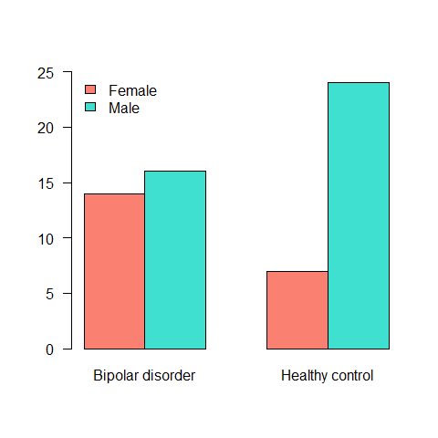

```r
table(data$Gender, data$Status) %>%
  barplot(., beside = TRUE,
          legend.text = TRUE,
          col = c('salmon','turquoise'),
          args.legend = list(x = 'topleft',
                             bty = 'n'),
          ylim = c(0,25),
          las = 1)
```

## Central tendency measures

The **central tendency measures** attempts to summarise/describe the dataset by its central position. The *mean*, *median* and *mode* are examples of central measurements.

The **five-number summary** is a set of descriptive statistics that provide information about a dataset. It consists of five quartiles:

1. $Q_0$ the lowest value of the sample, aka **Minimum**
2. $Q_1$ $25\%$ of the sample, aka **lower quantile**
3. $Q_2$ $50\%$ of the sample, aka **median**
4. $Q_3$ $75\%$ of the sample, aka **upper quantile**
5. $Q_4$ the biggest value of the sample, aka **Maximum**

The functions `summary()` and `fivenum()` returns the five-number summary. They are a bit different how they calculate the $1^{st}$ and $3^{rd}$ quantiles. `summary()` calculates the average of the two numbers, if even, `fivenum()` returns the minimum.

```r
### The function summary will give you an overview of the full data set if you want to!
summary(data)
```

```
##          X        Age_death       Age_onset     Alcohol_abuse
##  GSM123182: 1   Min.   :19.00   Min.   :14.00   Min.   :0.000
##  GSM123183: 1   1st Qu.:38.00   1st Qu.:18.25   1st Qu.:0.000
##  GSM123184: 1   Median :45.00   Median :22.00   Median :1.000
##  GSM123185: 1   Mean   :44.18   Mean   :24.03   Mean   :1.817
##  GSM123186: 1   3rd Qu.:49.00   3rd Qu.:27.75   3rd Qu.:3.250
##  GSM123187: 1   Max.   :64.00   Max.   :45.00   Max.   :5.000
##  (Other)  :55                   NA's   :31      NA's   :1
##     Brain_ph                  Status     Drug_abuse     Duration_illness
##  Min.   :5.920   Bipolar disorder:30   Min.   :0.0000   Min.   : 2.00
##  1st Qu.:6.400   Healthy control :31   1st Qu.:0.0000   1st Qu.:14.00
##  Median :6.600                         Median :0.0000   Median :18.50
##  Mean   :6.553                         Mean   :0.1935   Mean   :20.50
##  3rd Qu.:6.740                         3rd Qu.:0.0000   3rd Qu.:27.75
##  Max.   :7.030                         Max.   :3.0000   Max.   :45.00
##                                        NA's   :30       NA's   :31
##  Therapy_Electroconvulsive Therapy_Fluphenazine    Gender
##  No  :28                   Min.   :     0       Female:21
##  Yes : 2                   1st Qu.:     0       Male  :40
##  NA's:31                   Median :  3000
##                            Mean   : 11283
##                            3rd Qu.: 12000
##                            Max.   :130000
##                            NA's   :32
##  Therapy_Lithium Post_morten_interval Side_brain Suicide
##  No  :22         Min.   : 9.00        Left :32   No :49
##  Yes : 8         1st Qu.:23.00        Right:29   Yes:12
##  NA's:31         Median :31.00
##                  Mean   :33.05
##                  3rd Qu.:39.00
##                  Max.   :84.00
##
##  Therapy_Valproate     APOLD1          CLDN10          DUSP4
##  No  :20           Min.   :1.765   Min.   :1.822   Min.   :1.445
##  Yes :10           1st Qu.:1.917   1st Qu.:1.984   1st Qu.:1.522
##  NA's:31           Median :1.957   Median :2.042   Median :1.562
##                    Mean   :1.997   Mean   :2.042   Mean   :1.573
##                    3rd Qu.:2.113   3rd Qu.:2.113   3rd Qu.:1.632
##                    Max.   :2.286   Max.   :2.181   Max.   :1.718
##
```

[output cut: 41 more lines]

```
##  Min.   :1.808   Min.   :1.779   Min.   :1.640   Min.   :1.782
##  1st Qu.:1.986   1st Qu.:1.987   1st Qu.:1.768   1st Qu.:2.083
##  Median :2.017   Median :2.052   Median :2.227   Median :2.172
##  Mean   :2.004   Mean   :2.030   Mean   :2.065   Mean   :2.137
##  3rd Qu.:2.051   3rd Qu.:2.087   3rd Qu.:2.248   3rd Qu.:2.206
##  Max.   :2.109   Max.   :2.154   Max.   :2.280   Max.   :2.277
##
##      TAC1.1         TBL1XR1          USP9Y            XIST
##  Min.   :1.549   Min.   :1.504   Min.   :1.160   Min.   :1.424
##  1st Qu.:1.837   1st Qu.:1.742   1st Qu.:1.293   1st Qu.:1.462
##  Median :1.911   Median :1.805   Median :1.483   Median :1.497
##  Mean   :1.885   Mean   :1.789   Mean   :1.454   Mean   :1.701
##  3rd Qu.:1.974   3rd Qu.:1.856   3rd Qu.:1.589   3rd Qu.:2.106
##  Max.   :2.071   Max.   :1.990   Max.   :1.796   Max.   :2.264
##
```

```r
### or just the variable you want.
summary(data$Age_death)
```

```
##    Min. 1st Qu.  Median    Mean 3rd Qu.    Max.
##   19.00   38.00   45.00   44.18   49.00   64.00
```

```r
fivenum(data$Age_death)
```

```
## [1] 19 38 45 49 64
```

```r
###  (minimum, lower-hinge, median, upper-hinge, maximum)
```

The graphical representation of the summary is the `boxplot()`.

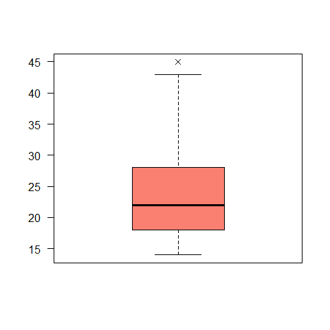

```r
boxplot(data$Age_onset,
        las = 2,
        pch = 4,
        col = 'salmon')
```

If we are interested in the summary **by** condition, we can use the function `by()`.

```r
by(data, data$Status,
   FUN = summary)
```

```
## data$Status: Bipolar disorder
##          X        Age_death       Age_onset     Alcohol_abuse
##  GSM123182: 1   Min.   :19.00   Min.   :14.00   Min.   :0.000
##  GSM123183: 1   1st Qu.:41.00   1st Qu.:18.25   1st Qu.:1.000
##  GSM123184: 1   Median :44.00   Median :22.00   Median :3.000
##  GSM123185: 1   Mean   :44.53   Mean   :24.03   Mean   :2.862
##  GSM123186: 1   3rd Qu.:50.75   3rd Qu.:27.75   3rd Qu.:5.000
##  GSM123187: 1   Max.   :64.00   Max.   :45.00   Max.   :5.000
##  (Other)  :24                                   NA's   :1
##     Brain_ph                  Status     Drug_abuse  Duration_illness
##  Min.   :5.920   Bipolar disorder:30   Min.   : NA   Min.   : 2.00
##  1st Qu.:6.355   Healthy control : 0   1st Qu.: NA   1st Qu.:14.00
##  Median :6.505                         Median : NA   Median :18.50
##  Mean   :6.475                         Mean   :NaN   Mean   :20.50
##  3rd Qu.:6.665                         3rd Qu.: NA   3rd Qu.:27.75
##  Max.   :6.970                         Max.   : NA   Max.   :45.00
##                                        NA's   :30
##  Therapy_Electroconvulsive Therapy_Fluphenazine    Gender
##  No :28                    Min.   :     0       Female:14
##  Yes: 2                    1st Qu.:     0       Male  :16
##                            Median :  3000
##                            Mean   : 11283
##                            3rd Qu.: 12000
##                            Max.   :130000
##                            NA's   :1
##  Therapy_Lithium Post_morten_interval Side_brain Suicide
##  No :22          Min.   :12.00        Left :18   No :18
##  Yes: 8          1st Qu.:23.25        Right:12   Yes:12
##                  Median :35.00
##                  Mean   :37.17
##                  3rd Qu.:47.00
##                  Max.   :84.00
##
##  Therapy_Valproate     APOLD1          CLDN10          DUSP4
##  No :20            Min.   :1.807   Min.   :1.889   Min.   :1.445
##  Yes:10            1st Qu.:1.941   1st Qu.:2.006   1st Qu.:1.506
##                    Median :1.983   Median :2.051   Median :1.540
##                    Mean   :2.024   Mean   :2.062   Mean   :1.548
##                    3rd Qu.:2.117   3rd Qu.:2.136   3rd Qu.:1.572
##                    Max.   :2.286   Max.   :2.181   Max.   :1.718
```

[output cut: 140 more lines]

```
##  Min.   :1.916   Min.   :1.930   Min.   :1.640   Min.   :1.996
##  1st Qu.:2.014   1st Qu.:2.003   1st Qu.:2.209   1st Qu.:2.172
##  Median :2.045   Median :2.081   Median :2.233   Median :2.197
##  Mean   :2.034   Mean   :2.060   Mean   :2.115   Mean   :2.189
##  3rd Qu.:2.056   3rd Qu.:2.103   3rd Qu.:2.249   3rd Qu.:2.225
##  Max.   :2.109   Max.   :2.154   Max.   :2.270   Max.   :2.275
##
##      TAC1.1         TBL1XR1          USP9Y            XIST
##  Min.   :1.760   Min.   :1.632   Min.   :1.160   Min.   :1.424
##  1st Qu.:1.897   1st Qu.:1.761   1st Qu.:1.393   1st Qu.:1.450
##  Median :1.945   Median :1.825   Median :1.540   Median :1.484
##  Mean   :1.944   Mean   :1.823   Mean   :1.502   Mean   :1.615
##  3rd Qu.:1.996   3rd Qu.:1.879   3rd Qu.:1.607   3rd Qu.:1.537
##  Max.   :2.071   Max.   :1.990   Max.   :1.796   Max.   :2.162
##
```

And the `boxplot()`:

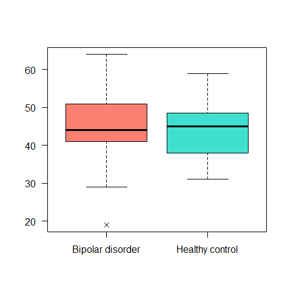

```r
boxplot(data$Age_death ~ data$Status,
        las = 1, pch = 4,
        col = c('salmon', 'turquoise'))
```

### Mean

It is calculated by taking the sum of the values and dividing by the total number of values of the data. The function `mean()` can be used to calculate the average.

```r
mean(data$Age_death)
```

```
## [1] 44.18033
```

**Interpretation**: On average, the age of death of death in this study was 44.1803279.

You can also use `colMeans()` and `rowMeans()` to compute the mean of columns and rows.

```r
colMeans(data[,c(17:28)], na.rm = T)
```

```
##   APOLD1   CLDN10    DUSP4   EFEMP1   ETNPPL     GJA1   PLSCR4     SDC4
## 1.997240 2.041634 1.572833 1.834842 2.183101 2.219369 1.902763 2.020990
##  SLC14A1     SOX9      SST     TAC1
## 1.339995 2.039741 2.137336 1.885281
```

```r
rowMeans(data[,17:28], na.rm = T)
```

```
##        1        2        3        4        5        6        7        8
## 2.012922 1.832557 1.840020 1.924146 1.962231 1.981616 1.945479 1.928857
##        9       10       11       12       13       14       15       16
## 1.941477 2.000882 1.874723 1.904858 1.995695 1.974847 1.949153 1.918931
##       17       18       19       20       21       22       23       24
## 1.934290 1.987450 1.958006 1.968084 1.991263 1.920940 1.984736 1.907677
##       25       26       27       28       29       30       31       32
## 1.984528 1.895546 1.952010 1.934318 1.876073 1.858500 1.876398 1.942668
##       33       34       35       36       37       38       39       40
## 1.885970 1.878481 1.817041 1.931009 1.960738 1.963836 1.923612 1.764979
##       41       42       43       44       45       46       47       48
## 1.916670 1.990174 1.864843 1.881532 1.986587 2.011588 1.996816 1.922206
##       49       50       51       52       53       54       55       56
## 1.888220 1.991758 1.944774 1.978649 1.859148 1.978678 1.982875 1.994539
##       57       58       59       60       61
## 1.851342 2.051429 1.809602 1.921640 1.897267
```

#### Median

It is the value that divides your dataset in the **middle**, the function`median()` computes it in R.

```r
median(data$Age_death)
```

```
## [1] 45
```

**Interpretation**: The mid-age of death in this study was 45. This means that this is the value that divides the data in half.

Note! The median is not always the same as the mean!

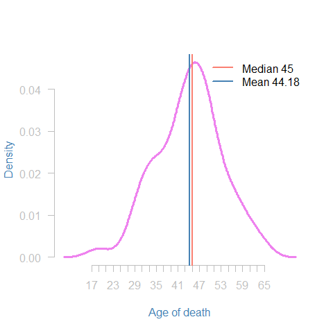

```r
# attach(data)
plot((density(data$Age_death))$x,(density(data$Age_death))$y,
     type = "l",
     xlab = "Age of death",
     ylab = "Density",
     las = 2,
     axes = F,
     col = "violet",
     lwd = 3,
     col.lab = "steelblue")
axis(1,
     at = seq(from = (round(min(data$Age_death))-2), by = 2, to = (2+round(max(data$Age_death)))),
     col = "gray75",
     col.axis = "gray75")
axis(2,
     las = 2,
     col = "gray75",
     col.ticks = "gray75",
     col.axis = "gray75")
abline(v = median(data$Age_death),
       col = "salmon",
       lwd = 2)
abline(v = mean(data$Age_death),
       col = "steelblue",
       lwd = 2)
legend("topright",
       c(paste("Median", round(median(data$Age_death),2)), paste("Mean", round(mean(data$Age_death),2))),
       col = c("salmon", "steelblue"),
       lwd = 2,
       bty = "n")
```

### Mode

The mode is the value that appears **the most on a variable**. It’s the *fashion* of the variable, the one that almost everyone is wearing. And sometimes there might exist more than one mode, but we won’t deal with it here.

Unfortunately, there is no function on R to compute the mode. But we already know how to construct tables and functions. So, let’s create our own function.

```r
Mode = function(VAR){
    actual_mode <- table(VAR)
    NAME = names(actual_mode)[actual_mode == max(actual_mode)]
    VAL = actual_mode[actual_mode == max(actual_mode)]
    return( data.frame(Value = NAME, Frequency = VAL))
}
```

```r
Mode(data$Age_onset)
```

|  | Value | Frequency |
| --- | --- | --- |
| 25 | 25 | 3 |

**Interpretation**: The most common age where people were diagnosed with bipolar disorder was 25 years.

## Dispersion measures

The dispersion refers to *how the values are spread* from the central data. It is as important as the central tendency values. Some of them are *Range*, *IQR*, *Variance* and *standard deviation*.

### Range

The range is the difference between the largest and the smallest value of a variable. The function `range()` returns the minimum and maximum values, to have the range we have to use the function `diff()`.

```r
range(data$Age_death) %>%
  diff(.)
```

```
## [1] 45
```

**Interpretation**: The difference (or the range) among the ages in our study was 45 years.

### Interquartile range (IQR)

Is the difference between the third and the first quartiles. It’s used to read and draw the boxplots. On R we can use the function IQR()

```r
IQR(data$Age_death)
```

```
## [1] 11
```

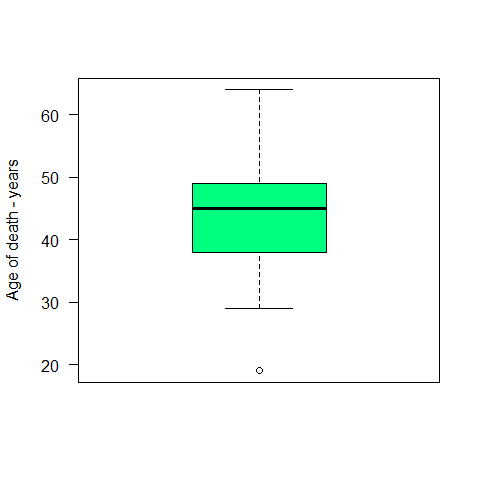

```r
boxplot(data$Age_death ,
        col = c ("springgreen"),
        ylab = "Age of death - years",
        las = 2)
```

```r
quantile(data$Age_death)
```

```
##   0%  25%  50%  75% 100%
##   19   38   45   49   64
```

### Variance

Variance is the expectation of the squared deviation of a random variable from its mean. In other words, the variance is how far the values are from the mean. We can calculate it using the function `var()`.

```r
var(data$Age_death)
```

```
## [1] 82.38361
```

**Interpretation**: The age of the individuals in our study deviates from the mean in 82.3836066 years$^2$ (quadratic scale). However, it is quite hard to make interpretations in years$^2$.

### Standard deviation (SD)

Is how the values are spread around the mean. It is given by the square root of the variance. A low standard deviation indicates that the data points tend to be close to the mean, while a high standard deviation indicates that the data points are spread out over a wider range of values. To compute the SD using R we can use the function `sd()`.

```r
sd(data$Age_death)
```

```
## [1] 9.076542
```

```r
sqrt(var(data$Age_death))
```

```
## [1] 9.076542
```

**Interpretation**: The age of the individuals in our study deviates from the mean in 9.0765416 years (data scale).

### Coefficient of variation

The coefficient of variation is the sd divided by the mean. In chemistry is widely used to express the precision and repeatability of an experiment. Normally it is expressed as a percentage. The CV aims to describe the dispersion of the variable in a way that does not depend on the variable’s measurement unit. The higher the CV, the greater the dispersion in the variable.

It’s also used to compare the variation of variables that are not on the same scale.

```r
sd(sd(data$Age_death))/mean(sd(data$Age_death))*100
```

```
## [1] NA
```

```r
CV <- function(VAR){
      (sd(VAR, na.rm = T)/mean(VAR, na.rm = T))*100
      }
```

```r
CV(sd(data$Age_death))
```

```
## [1] NA
```

## Exercises

1. Make absolute and relative frequency tables for the variables: Gender and Status.
2. Check how many people that suffered from Bipolar Disorder committed suicide. Visualise it using a barplot.
3. Compute and make the correct interpretations for the mean, median, IQR, standard deviation, variance and CV for all the quantitative variables. Tipp: You can create a function for that!
4. Compute and make the correct interpretations for the mean, median, IQR, standard deviation, variance and CV for all the numeric variables only for Males. Tipp: Use the function created before on a subset of the dataset.
5. Compute and make the correct interpretations for the mean, median, IQR, standard deviation, variance and CV for all the quantitative variables for both conditions separately.